# Testing on Jill Kucab’s Data (Media Control)

Xinyi

2023-02-14

# Load packages

```r
library(ICAMS)
library(philentropy)
library(factoextra)
```

```r
library(gplots)
library(nloptr)
devtools::load_all(".")
```

```
## ℹ Loading mSigBG
```

# Functions for this File

```r
pcat <- function(catalog) {
  par(pin = c(3*ncol(catalog), 1))
  par(mfrow = c(ncol(catalog), 1))
  par(mar = c(2, 4, 4, 2))
  par(cex = 0.8)
  par(cex.main = 1.4)
  xlabels <- FALSE
  for (i in 1:ncol(catalog)) {
    if (FALSE && i == ncol(catalog)) { # FALSE an experiment
      xlabels <- TRUE
      par(mar = c(4.5, 4, 3, 2))
    }

    ICAMS::PlotCatalog(catalog[ , i, drop = FALSE],
                       upper = (i == 1),
                       xlabels = xlabels)
  }
}
```

```r
convert_base <- function(x){
  if (x == "A")
    ret <- "T"
  else if (x == "C")
    ret <- "G"
  else if (x == "G")
    ret <- "C"
  else if (x == "T")
    ret <- "A"
  else{
    message("Incorrent input")
    ret <- 0
  }

  return(ret)
}
```

```r
Jill_to_SBS96 <- function(input_table){
  subs <- input_table[,c("pre_context","Ref","rear_context","Alt")]
  for (i in 1:nrow(input_table)){
    if (subs[i,2] == "A" | subs[i,2] =="G"){
      tmp1 <- convert_base(subs[i,1])
      tmp2 <- convert_base(subs[i,2])
      tmp3 <- convert_base(subs[i,3])
      tmp4 <- convert_base(subs[i,4])
      subs[i,1] <- tmp3
      subs[i,2] <- tmp2
      subs[i,3] <- tmp1
      subs[i,4] <- tmp4
    }
  }
  subs.pasted <- apply(subs, MARGIN = 1, function(x){paste0(x[1], x[2], x[3], x[4])})
  SBS96.template <- c("ACAA", "ACCA", "ACGA", "ACTA", "CCAA", "CCCA", "CCGA", "CCTA",
                      "GCAA", "GCCA", "GCGA", "GCTA", "TCAA", "TCCA", "TCGA", "TCTA",
                      "ACAG", "ACCG", "ACGG", "ACTG", "CCAG", "CCCG", "CCGG", "CCTG",
                      "GCAG", "GCCG", "GCGG", "GCTG", "TCAG", "TCCG", "TCGG", "TCTG",
                      "ACAT", "ACCT", "ACGT", "ACTT", "CCAT", "CCCT", "CCGT", "CCTT",
                      "GCAT", "GCCT", "GCGT", "GCTT", "TCAT", "TCCT", "TCGT", "TCTT",
                      "ATAA", "ATCA", "ATGA", "ATTA", "CTAA", "CTCA", "CTGA", "CTTA",
                      "GTAA", "GTCA", "GTGA", "GTTA", "TTAA", "TTCA", "TTGA", "TTTA",
                      "ATAC", "ATCC", "ATGC", "ATTC", "CTAC", "CTCC", "CTGC", "CTTC",
                      "GTAC", "GTCC", "GTGC", "GTTC", "TTAC", "TTCC", "TTGC", "TTTC",
                      "ATAG", "ATCG", "ATGG", "ATTG", "CTAG", "CTCG", "CTGG", "CTTG",
                      "GTAG", "GTCG", "GTGG", "GTTG", "TTAG", "TTCG", "TTGG", "TTTG")
  subs.spectra <- rep(0,96)
  names(subs.spectra) <- SBS96.template

  # count occurrence
  for (i in subs.pasted){
    subs.spectra[i] <- subs.spectra[i] + 1
  }

  subs.cat <- as.catalog(as.matrix(subs.spectra), ref.genome = "GRCh37", region = "genome", catalog.type = "counts" , infer.rownames = TRUE)

  return(subs.cat)
}
```

```r
one.separation <- function(sig.name, spectra, bg.sig.info, my.seed = 101010) {

  set.seed(my.seed, kind = "L'Ecuyer-CMRG")

  if (is.null(attr(spectra, "abundance"))) {
    stop("NULL abundance for ", sig.name)
  }

  ret <- SeparateSignatureAndSpectra(
    spectra          = spectra,
    bg.sig.info      = bg.sig.info,
    m.opts           = NULL,
    start.b.fraction = 0.5,
    sig.name         = sig.name
  )

  return(ret)
}
```

#### Two Ways of getting Inferred spectra

##### Method 1: obs.spectra - (bg.exposure * the background signature)

Inferred spectra obtained from observed spectra minus background spectra

```r
target_sig_M1 <- function(obs.spectra, spectra.sep) {
  bg.exposure <- spectra.sep$exposures.to.bg.sig
  bg.spectra <- spectra.sep$inferred.bg.spectra
  bg.sig <- spectra.sep$inferred.bg.spectra/colSums(bg.spectra)

  target.spectra <- obs.spectra[,1, drop=FALSE]  - bg.exposure[1] * bg.sig[, 1, drop=FALSE]
  if(length(bg.exposure)>1){
    for (i in 2:length(bg.exposure)){
      target.spectra <- cbind(target.spectra, obs.spectra[,i, drop=FALSE]  - bg.exposure[i] * bg.sig[, i, drop=FALSE])
    }
  }
  #target.sig.method1 <- target.spectra/colSums(target.spectra) # convert clonal target spectra to signature

  return(target.spectra)
  #return(target.sig.method1)
}
```

##### Method 2: (obs.counts - bg.exposure) * sig.to.return

Inferred spectra obtained from inferred target signature multiply # of target mutations (observed -bg)

```r
# No. of mutation due to bg in each sample
target_sig_M2 <- function(obs.spectra, spectra.sep){
  bg.exposures <- spectra.sep$exposures.to.bg.sig
  names(bg.exposures) <- sub("-inf.bg.spect", "", colnames(spectra.sep$inferred.bg.spectra), fixed = TRUE)

  target.sig <-spectra.sep$inferred.target.sig.as.catalog

  inferred.target.count <- sum(obs.spectra[,1]) - bg.exposures[1]
  target.spec.method2 <- inferred.target.count * target.sig

  if(length(bg.exposures>1)){
    for (j in 2:length(bg.exposures)){
      inferred.target.count <- sum(obs.spectra[,j]) - bg.exposures[j]
      temp.inferred.spectra <- inferred.target.count * target.sig
      target.spec.method2 <- cbind(target.spec.method2,temp.inferred.spectra)
    }
  }
  return(target.spec.method2)
}
```

# Read Input from Jill Kucab’s data

```r
sig.all <- read.table("Jill_Mutagen53_sub_signature.txt",header = TRUE, sep ="\t")

subs.all <- read.table("Jill_denovo_subclone_subs_final.txt",header = TRUE, sep ="\t")
```

# Extract the data we need

The Controls: MSM0.118 DMSO Control (0.5%) + HS9 MSM0.119 DMSO Control (0.5%) + S9 MSM0.131 DMSO Control (0.1%) + S9 MSM0.4 DMSO Control (0.68%) MSM0.86 DMSO Control (0.35%) + S9 MSM0.9 DMSO Control (0.1%) MSM0.1 H2O Control (0.1%) MSM0.45 H2O Control (0.1%) MSM0.8 Media Control MSM0.128 Media Control MSM0.129 Media Control + S9 MSM0.120 MeOH Control (1.3%) MSM0.127 MeOH Control (4.3%) + S9 MSM0.6 NaCl Control (0.003%) MSM0.37 DMSO Control (0.1%) + S9

The Exposures: MSM0.72 Carboplatin (5 uM) MSM0.7 Cisplatin (3.125 uM) MSM0.83 Cisplatin (12.5 uM)

```r
H2O.1 <- subs.all[grep("MSM0.1_", subs.all[,3]), ,drop = FALSE]
H2O.2 <- subs.all[grep("MSM0.45_", subs.all[,3]), ,drop = FALSE]
NaCl <- subs.all[grep("MSM0.6_", subs.all[,3]), ,drop = FALSE]
Media.1 <- subs.all[grep("MSM0.8_", subs.all[,3]), ,drop = FALSE]
Media.2 <- subs.all[grep("MSM0.128_", subs.all[,3]), ,drop = FALSE]
```

[output not shown]

[output not shown]

[output not shown]

Read the controls

```r
# Media control
Media_1.1 <- Jill_to_SBS96(subs.all[grep("MSM0.8_s1", subs.all[,3]), ,drop = FALSE])
Media_1.2 <- Jill_to_SBS96(subs.all[grep("MSM0.8_s2", subs.all[,3]), ,drop = FALSE])
Media_2.1 <- Jill_to_SBS96(subs.all[grep("MSM0.128_s2", subs.all[,3]), ,drop = FALSE])
Media_2.2 <- Jill_to_SBS96(subs.all[grep("MSM0.128_s3", subs.all[,3]), ,drop = FALSE])
Media_2.3 <- Jill_to_SBS96(subs.all[grep("MSM0.128_s4", subs.all[,3]), ,drop = FALSE])

Media_ctrl <- cbind(Media_1.1, Media_1.2, Media_2.1, Media_2.2, Media_2.3)

# H2O control
H2O.1.1 <- Jill_to_SBS96(subs.all[grep("MSM0.1_s1", subs.all[,3]), ,drop = FALSE])
H2O.1.2 <- Jill_to_SBS96(subs.all[grep("MSM0.1_s2", subs.all[,3]), ,drop = FALSE])
H2O.2.1 <- Jill_to_SBS96(subs.all[grep("MSM0.45_s1", subs.all[,3]), ,drop = FALSE])
H2O.2.2 <- Jill_to_SBS96(subs.all[grep("MSM0.45_s2", subs.all[,3]), ,drop = FALSE])

H2O_ctrl <- cbind(H2O.1.1, H2O.1.2, H2O.2.1, H2O.2.2)
```

The Controls: MSM0.118 DMSO Control (0.5%) + HS9 MSM0.119 DMSO Control (0.5%) + S9 MSM0.131 DMSO Control (0.1%) + S9

MSM0.4 DMSO Control (0.68%) MSM0.86 DMSO Control (0.35%) + S9 MSM0.9 DMSO Control (0.1%)

MSM0.1 H2O Control (0.1%) MSM0.45 H2O Control (0.1%)

MSM0.8 Media Control MSM0.128 Media Control MSM0.129 Media Control + S9

MSM0.120 MeOH Control (1.3%) MSM0.127 MeOH Control (4.3%) + S9

MSM0.6 NaCl Control (0.003%) MSM0.37 DMSO Control (0.1%) + S9

```r
DMSO_0.5_HS9 <- Jill_to_SBS96(subs.all[grep("MSM0.118", subs.all[,3]), ,drop = FALSE])
DMSO_0.5_S9 <- Jill_to_SBS96(subs.all[grep("MSM0.119", subs.all[,3]), ,drop = FALSE])
DMSO_0.1_S9 <- Jill_to_SBS96(subs.all[grep("MSM0.131", subs.all[,3]), ,drop = FALSE])
DMSO_0.68 <- Jill_to_SBS96(subs.all[grep("MSM0.4", subs.all[,3]), ,drop = FALSE])
DMSO_0.35_S9 <- Jill_to_SBS96(subs.all[grep("MSM0.86", subs.all[,3]), ,drop = FALSE])
DMSO_0.1 <- Jill_to_SBS96(subs.all[grep("MSM0.9", subs.all[,3]), ,drop = FALSE])
H2O_0.1 <- Jill_to_SBS96(subs.all[grep("MSM0.1", subs.all[,3]), ,drop = FALSE])
H2O_0.1_ <- Jill_to_SBS96(subs.all[grep("MSM0.45", subs.all[,3]), ,drop = FALSE])

Media <- Jill_to_SBS96(subs.all[grep("MSM0.8", subs.all[,3]), ,drop = FALSE])
Media_ <- Jill_to_SBS96(subs.all[grep("MSM0.128", subs.all[,3]), ,drop = FALSE])
Media_S9 <- Jill_to_SBS96(subs.all[grep("MSM0.4", subs.all[,3]), ,drop = FALSE])

MeOH_1.3 <- Jill_to_SBS96(subs.all[grep("MSM0.120", subs.all[,3]), ,drop = FALSE])
MeOH_4.3_S9 <- Jill_to_SBS96(subs.all[grep("MSM0.127", subs.all[,3]), ,drop = FALSE])
NaCl_0.003 <- Jill_to_SBS96(subs.all[grep("MSM0.6", subs.all[,3]), ,drop = FALSE])
DMSO_0.1_S9_ <- Jill_to_SBS96(subs.all[grep("MSM0.37", subs.all[,3]), ,drop = FALSE])

all.controls <- cbind(DMSO_0.5_HS9,DMSO_0.5_S9,DMSO_0.1_S9,
                      DMSO_0.68, DMSO_0.35_S9, DMSO_0.1,
                      H2O_0.1,H2O_0.1_,
                      Media, Media_, Media_S9,
                      MeOH_1.3, MeOH_4.3_S9,NaCl_0.003,DMSO_0.1_S9_)
```

```r
control.names <- c("MSM0.118", "MSM0.119", "MSM0.131", "MSM0.4", "MSM0.86", "MSM0.9",
                   "MSM0.1", "MSM0.45", "MSM0.8", "MSM0.128","MSM0.129",
                   "MSM0.120", "MSM0.127", "MSM0.6", "MSM0.37")
```

```r
for (i in control.names)
  print(dim(unique(subs.all[grep(i, subs.all[,3]), ,drop = FALSE]['Sample']))[1])
```

```
## [1] 2
## [1] 2
## [1] 3
## [1] 28
## [1] 2
## [1] 28
## [1] 115
## [1] 2
## [1] 24
## [1] 3
## [1] 3
## [1] 3
## [1] 2
## [1] 28
## [1] 2
```

```r
all.controls.scaled <- cbind(DMSO_0.5_HS9/2,DMSO_0.5_S9/2,DMSO_0.1_S9/3,
                      DMSO_0.68/28, DMSO_0.35_S9/2, DMSO_0.1/28,
                      H2O_0.1/115,H2O_0.1_/2,
                      Media/24, Media_/3, Media_S9/3,
                      MeOH_1.3/3, MeOH_4.3_S9/2,NaCl_0.003/28,DMSO_0.1_S9_/2)
```

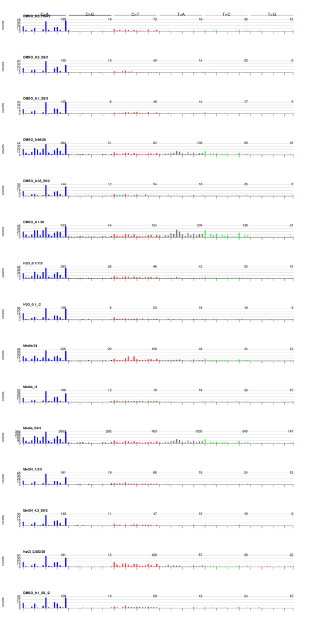

```r
pcat(all.controls.scaled)
```

```r
# Carboplatin
carb <- cbind(Jill_to_SBS96(subs.all[grep("MSM0.72_s1", subs.all[,3]), ,drop = FALSE]),
              Jill_to_SBS96(subs.all[grep("MSM0.72_s2", subs.all[,3]), ,drop = FALSE]),
              Jill_to_SBS96(subs.all[grep("MSM0.72_s3", subs.all[,3]), ,drop = FALSE]))
colnames(carb)<- paste0("carboplatin_s", rep(1:3))

# Cisplatin
cis.less <- cbind(Jill_to_SBS96(subs.all[grep("MSM0.7_s4", subs.all[,3]), ,drop = FALSE]),
              Jill_to_SBS96(subs.all[grep("MSM0.7_s5", subs.all[,3]), ,drop = FALSE]),
              Jill_to_SBS96(subs.all[grep("MSM0.7_s6", subs.all[,3]), ,drop = FALSE]))
cis.more <- cbind(Jill_to_SBS96(subs.all[grep("MSM0.83_s1", subs.all[,3]), ,drop = FALSE]),
              Jill_to_SBS96(subs.all[grep("MSM0.83_s2", subs.all[,3]), ,drop = FALSE]),
              Jill_to_SBS96(subs.all[grep("MSM0.83_s3", subs.all[,3]), ,drop = FALSE]))

colnames(cis.less)<- paste0("cisplatin_3.125uM", rep(1:3))
colnames(cis.more)<- paste0("cisplatin_12.5uM", rep(1:3))
```

Generate BG info

```r
bg.media <- MakeBackgroundInfo(all.controls)
```

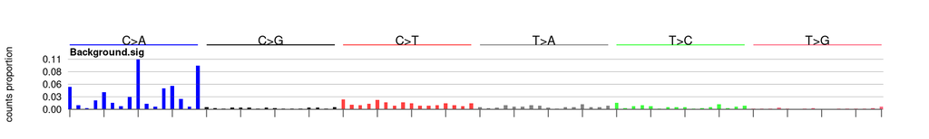

```r
pcat(bg.media$background.sig)
```

# comparison across controls

```r
Media_ctrl <- all.controls
colnames <- c()
pw.sim = matrix(data=NA, nrow=1, ncol=0)
for (i in 1:(ncol(Media_ctrl)-1)){
  for (j in (i+1):ncol(Media_ctrl)){
    tmp.sim <- philentropy::cosine_dist(Media_ctrl[,i,drop=FALSE],Media_ctrl[,j,drop=FALSE], testNA=TRUE)
    colnames <- c(colnames, paste(colnames(Media_ctrl)[i],
                                  colnames(Media_ctrl)[j],
                                  sep="-"))
    pw.sim <- cbind(pw.sim, tmp.sim)
  }
}
colnames(pw.sim) <- colnames
mean(pw.sim)
```

```
## [1] 0.9179639
```

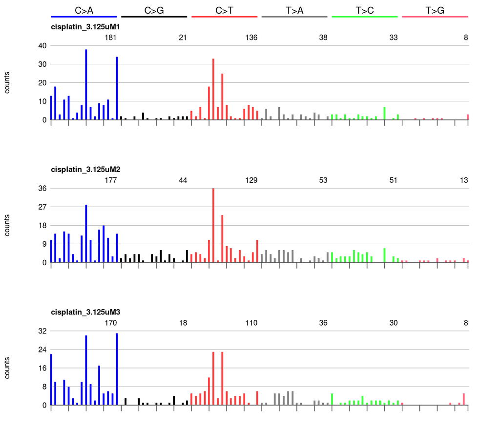

```r
pcat(cis.less)
```

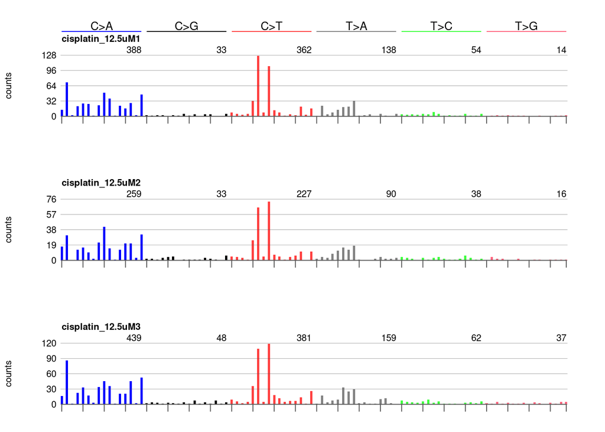

```r
pcat(cis.more)
```

```r
Jill.car.sep <- one.separation("Jill.car", carb, bg.media)
Jill.cis.less.sep <- one.separation("Jill.cis.less", cis.less, bg.media)
Jill.cis.more.sep <- one.separation("Jill.cis.more", cis.more, bg.media)
```

```r
ts.car <- target_sig_M1(carb, Jill.car.sep)
ts.cis.less <- target_sig_M1(cis.less, Jill.cis.less.sep)
ts.cis.more <- target_sig_M1(cis.more, Jill.cis.more.sep)
```

## Cisplatin (less) inferred Target Signature

### MSM0.7 Cisplatin (3.125 uM)

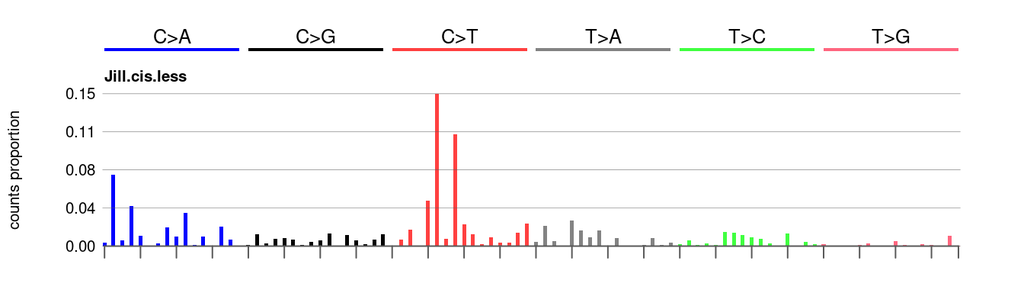

```r
pcat(Jill.cis.less.sep$inferred.target.sig.as.catalog)
```

```r
philentropy::cosine_dist(Jill.cis.less.sep$inferred.target.sig.as.catalog,
                         as.catalog(sig.all[,"Cisplatin..3.125.uM.", drop = FALSE], catalog.type = "counts.signature", infer.rownames = TRUE),
                         testNA = FALSE)
```

```
## [1] 0.9859736
```

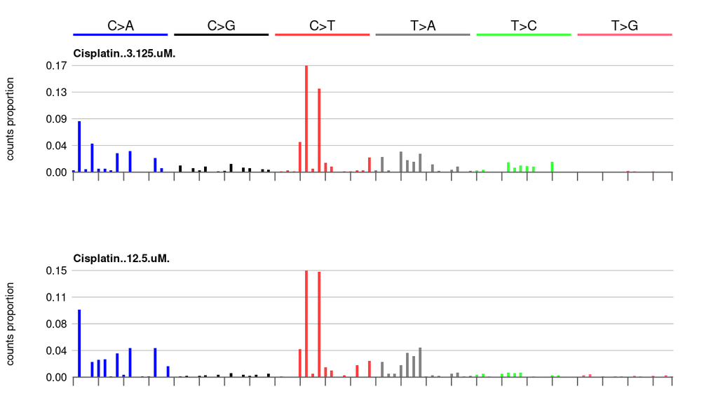

```r
# Signature derived in Jill's paper
Jill.cis.sig <- cbind(sig.all[,"Cisplatin..3.125.uM.", drop = FALSE], sig.all[,"Cisplatin..12.5.uM.", drop = FALSE])

pcat(as.catalog(Jill.cis.sig, catalog.type = "counts.signature", infer.rownames = TRUE))
```

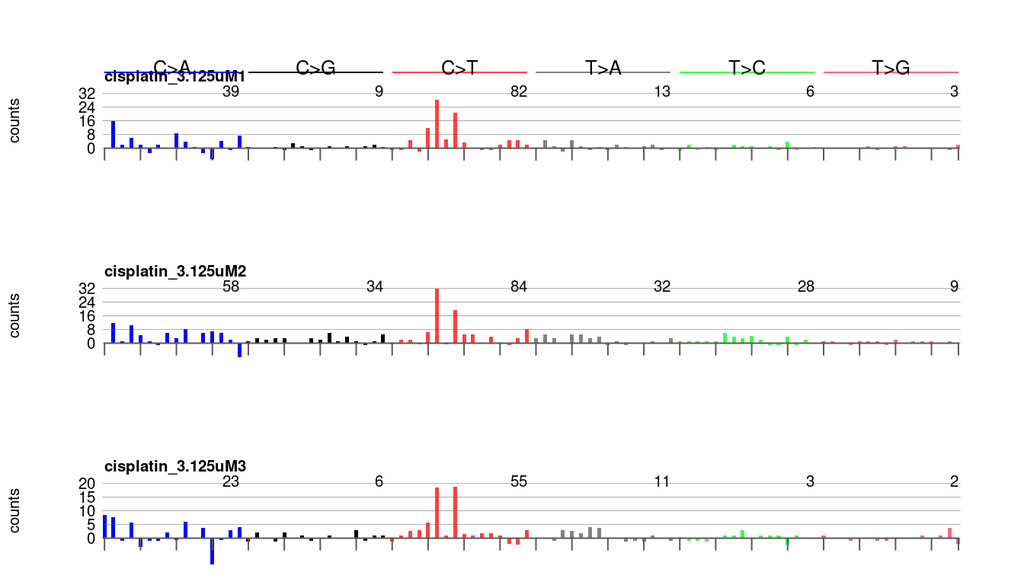

```r
pcat(ts.cis.less)
```

Overall pairwise cosine similarity

```r
colnames <- c()
pw.sim = matrix(data=NA, nrow=1, ncol=0)
x=1
for (i in 1:(ncol(ts.cis.less)-1)){
  for (j in (i+1):ncol(ts.cis.less)){
    tmp.sim <- philentropy::cosine_dist(ts.cis.less[,i,drop=FALSE],ts.cis.less[,j,drop=FALSE], testNA=TRUE)
    colnames <- c(colnames, paste(colnames(ts.cis.less)[i],
                                  colnames(ts.cis.less)[j],
                                  sep="-"))
    pw.sim <- cbind(pw.sim, tmp.sim)
  }
}
colnames(pw.sim) <- colnames
rownames(pw.sim) <- names(tmp.sim)

pw.sim
```

```
##      cisplatin_3.125uM1-cisplatin_3.125uM2
## [1,]                             0.7453603
##      cisplatin_3.125uM1-cisplatin_3.125uM3
## [1,]                             0.7373727
##      cisplatin_3.125uM2-cisplatin_3.125uM3
## [1,]                              0.684732
```

Heat Map of clonal cisplatin comparison

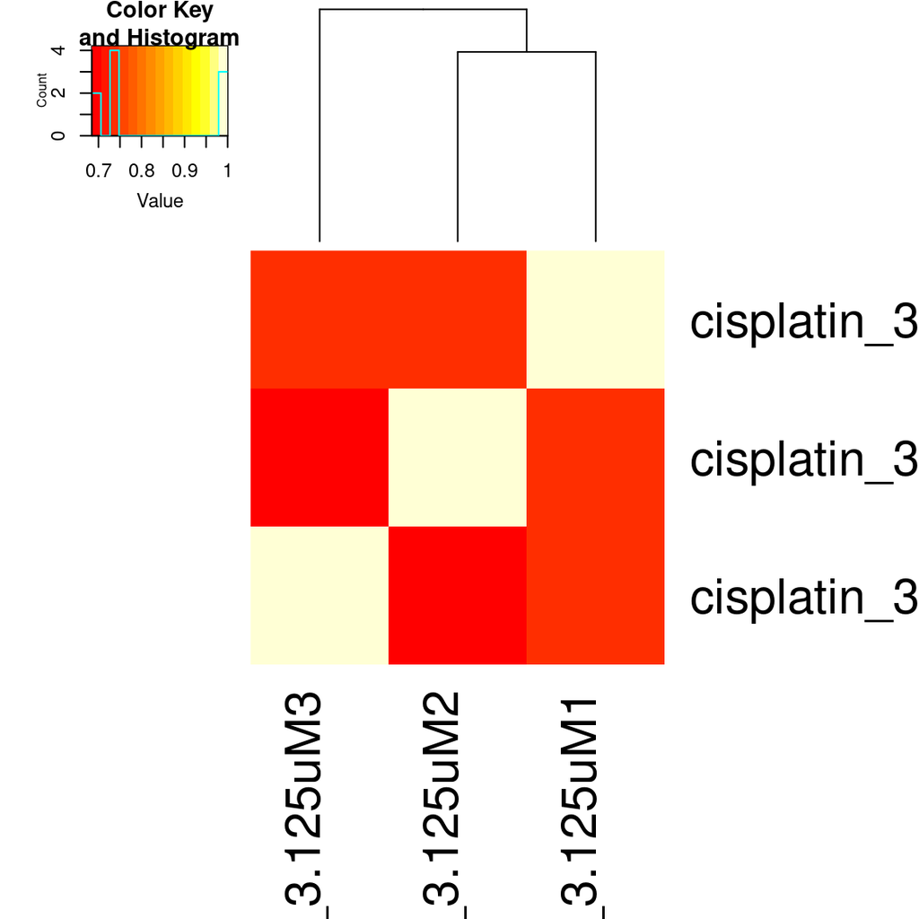

```r
cosine.sim <- suppressMessages(
  philentropy::distance(t(ts.cis.less), method = "cosine"))

colnames(cosine.sim) <- colnames(ts.cis.less)
rownames(cosine.sim) <- colnames(ts.cis.less)
gplots::heatmap.2(x = cosine.sim,
                  dendrogram = "column",
                  margins = c(10, 10),
                  cex.axis = 2,
                  symm = TRUE,
                  trace = "none")
```

Weighted cosine similarity

```r
colnames <- c()
pw.subsim <- c()
x=1
for (i in 1:(ncol(ts.cis.less)-1)){
  for (j in (i+1):ncol(ts.cis.less)){
    tmp.subsim <- subcolor_sim(ts.cis.less[,i,drop=FALSE],ts.cis.less[,j,drop=FALSE])[["weighted.avg"]]
    colnames <- c(colnames, paste(colnames(ts.cis.less)[i],
                                  colnames(ts.cis.less)[j],
                                  sep="-"))
    pw.subsim <- c(pw.subsim, tmp.subsim)
  }
}
names(pw.subsim) <- colnames
pw.subsim
```

```
## cisplatin_3.125uM1-cisplatin_3.125uM2 cisplatin_3.125uM1-cisplatin_3.125uM3
##                             0.6252585                             0.6212422
## cisplatin_3.125uM2-cisplatin_3.125uM3
##                             0.5615059
```

Cosine similarity by color

```r
colnames <- c()
pw.subsim = matrix(data=NA, nrow=6, ncol=0)
x=1
for (i in 1:(ncol(ts.cis.less)-1)){
  for (j in (i+1):ncol(ts.cis.less)){
    tmp.subsim <- subcolor_sim(ts.cis.less[,i,drop=FALSE],ts.cis.less[,j,drop=FALSE])[["by.color"]]
    colnames <- c(colnames, paste(colnames(ts.cis.less)[i],
                                  colnames(ts.cis.less)[j],
                                  sep="-"))
    pw.subsim <- cbind(pw.subsim, tmp.subsim)
  }
}
colnames(pw.subsim) <- colnames
rownames(pw.subsim) <- names(tmp.subsim)

pw.subsim
```

```
##     cisplatin_3.125uM1-cisplatin_3.125uM2 cisplatin_3.125uM1-cisplatin_3.125uM3
## C>A                            0.39326588                            0.55362134
## C>G                            0.24544831                            0.01327568
## C>T                            0.92435821                            0.91105942
## T>A                            0.63637462                            0.09555220
## T>C                            0.48952884                           -0.29355227
## T>G                            0.09326889                           -0.47943870
##     cisplatin_3.125uM2-cisplatin_3.125uM3
## C>A                            0.25888465
## C>G                            0.34805484
## C>T                            0.93061631
## T>A                            0.52650356
## T>C                            0.09042077
## T>G                            0.33822203
```

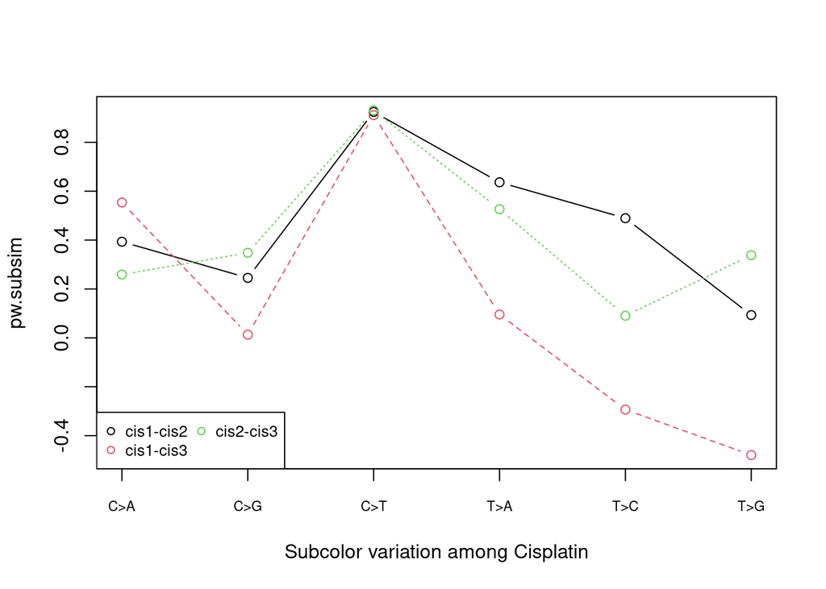

```r
matplot(pw.subsim, type = "b",pch=1, col = 1:21, xaxt = "n", xlab = "Subcolor variation among Cisplatin")
axis(1, at = 1:6, labels = rownames(pw.subsim), cex.axis = 0.7)
legend("bottomleft", legend = gsub("platin_3.125uM", "", colnames(pw.subsim), fix=TRUE), ncol=2, col=1:21, pch=1, cex = 0.8)
```

## Cisplatin (more) inferred Target Signature

### MSM0.83 Cisplatin (12.5 uM)

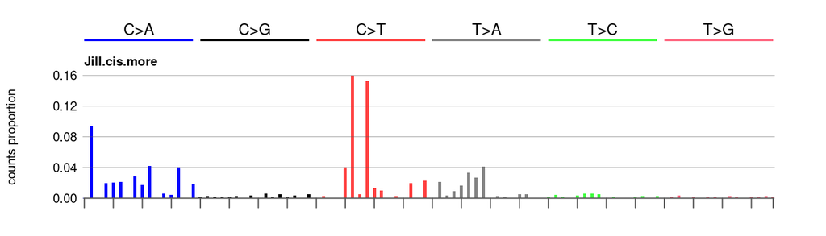

```r
pcat(Jill.cis.more.sep$inferred.target.sig.as.catalog)
```

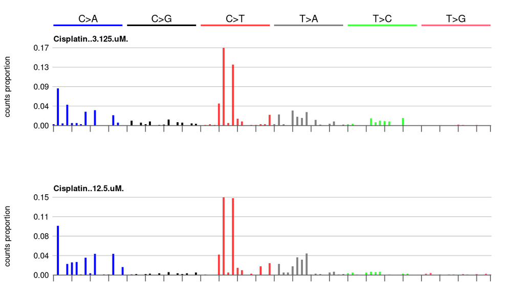

```r
# Signature derived in Jill's paper
Jill.cis <- cbind(sig.all[,"Cisplatin..3.125.uM.", drop = FALSE], sig.all[,"Cisplatin..12.5.uM.", drop = FALSE])

pcat(as.catalog(Jill.cis,catalog.type = "counts.signature", infer.rownames = TRUE))
```

```r
philentropy::cosine_dist(Jill.cis.more.sep$inferred.target.sig.as.catalog,
                         as.catalog(sig.all[,"Cisplatin..12.5.uM.", drop = FALSE], catalog.type = "counts.signature", infer.rownames = TRUE),
                         testNA = FALSE)
```

```
## [1] 0.9969481
```

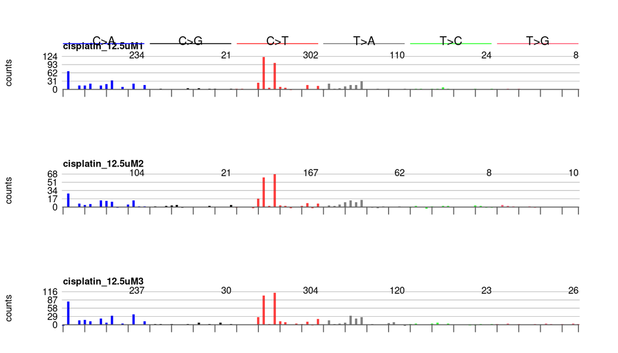

```r
pcat(ts.cis.more)
```

Overall pairwise cosine similarity

```r
colnames <- c()
pw.sim = matrix(data=NA, nrow=1, ncol=0)
x=1
for (i in 1:(ncol(ts.cis.more)-1)){
  for (j in (i+1):ncol(ts.cis.more)){
    tmp.sim <- philentropy::cosine_dist(ts.cis.more[,i,drop=FALSE],ts.cis.more[,j,drop=FALSE], testNA=TRUE)
    colnames <- c(colnames, paste(colnames(ts.cis.more)[i],
                                  colnames(ts.cis.more)[j],
                                  sep="-"))
    pw.sim <- cbind(pw.sim, tmp.sim)
  }
}
colnames(pw.sim) <- colnames
rownames(pw.sim) <- names(tmp.sim)

pw.sim
```

```
##      cisplatin_12.5uM1-cisplatin_12.5uM2 cisplatin_12.5uM1-cisplatin_12.5uM3
## [1,]                           0.9630127                           0.9700815
##      cisplatin_12.5uM2-cisplatin_12.5uM3
## [1,]                           0.9572043
```

Heat Map of clonal cisplatin comparison

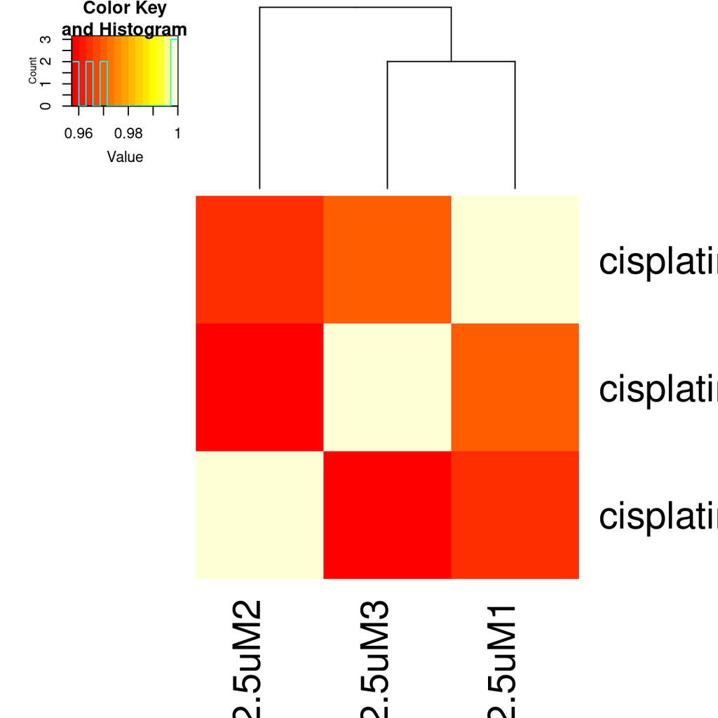

```r
cosine.sim <- suppressMessages(
  philentropy::distance(t(ts.cis.more), method = "cosine"))

colnames(cosine.sim) <- colnames(ts.cis.more)
rownames(cosine.sim) <- colnames(ts.cis.more)
gplots::heatmap.2(x = cosine.sim,
                  dendrogram = "column",
                  margins = c(7, 7),
                  cex.axis = 2,
                  symm = TRUE,
                  trace = "none")
```

Weighted cosine similarity

```r
colnames <- c()
pw.subsim <- c()
x=1
for (i in 1:(ncol(ts.cis.more)-1)){
  for (j in (i+1):ncol(ts.cis.more)){
    tmp.subsim <- subcolor_sim(ts.cis.more[,i,drop=FALSE],ts.cis.more[,j,drop=FALSE])[["weighted.avg"]]
    colnames <- c(colnames, paste(colnames(ts.cis.more)[i],
                                  colnames(ts.cis.more)[j],
                                  sep="-"))
    pw.subsim <- c(pw.subsim, tmp.subsim)
  }
}
names(pw.subsim) <- colnames
pw.subsim
```

```
## cisplatin_12.5uM1-cisplatin_12.5uM2 cisplatin_12.5uM1-cisplatin_12.5uM3
##                           0.9185174                           0.9253862
## cisplatin_12.5uM2-cisplatin_12.5uM3
##                           0.8962528
```

Cosine similarity by color

```r
colnames <- c()
pw.subsim = matrix(data=NA, nrow=6, ncol=0)
x=1
for (i in 1:(ncol(ts.cis.more)-1)){
  for (j in (i+1):ncol(ts.cis.more)){
    tmp.subsim <- subcolor_sim(ts.cis.more[,i,drop=FALSE],ts.cis.more[,j,drop=FALSE])[["by.color"]]
    colnames <- c(colnames, paste(colnames(ts.cis.more)[i],
                                  colnames(ts.cis.more)[j],
                                  sep="-"))
    pw.subsim <- cbind(pw.subsim, tmp.subsim)
  }
}
colnames(pw.subsim) <- colnames
rownames(pw.subsim) <- names(tmp.subsim)

pw.subsim
```

```
##     cisplatin_12.5uM1-cisplatin_12.5uM2 cisplatin_12.5uM1-cisplatin_12.5uM3
## C>A                           0.9392902                           0.9624686
## C>G                           0.5089993                           0.5168569
## C>T                           0.9859217                           0.9870710
## T>A                           0.8980328                           0.9113352
## T>C                           0.5526206                           0.5317366
## T>G                           0.5248211                           0.5596964
##     cisplatin_12.5uM2-cisplatin_12.5uM3
## C>A                           0.9387785
## C>G                           0.4105964
## C>T                           0.9950176
## T>A                           0.9101991
## T>C                           0.2762553
## T>G                           0.3453427
```

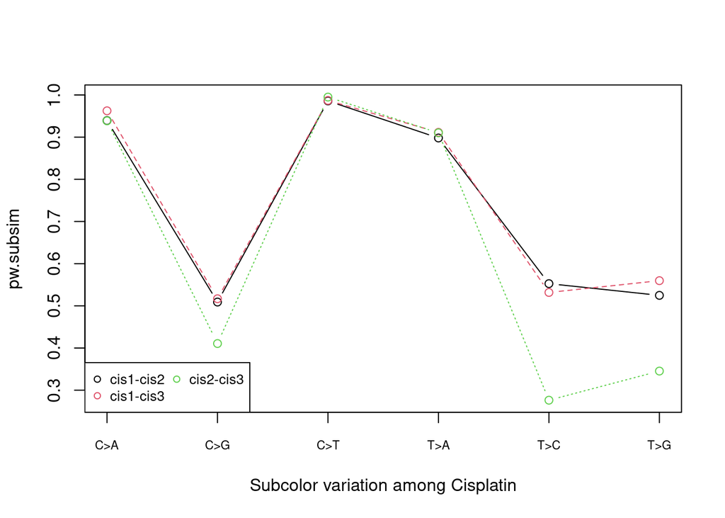

```r
matplot(pw.subsim, type = "b",pch=1, col = 1:21, xaxt = "n", xlab = "Subcolor variation among Cisplatin")
axis(1, at = 1:6, labels = rownames(pw.subsim), cex.axis = 0.7)
legend("bottomleft", legend = gsub("platin_12.5uM", "", colnames(pw.subsim), fix=TRUE), ncol=2, col=1:21, pch=1, cex = 0.8)
```

## Carboplatin inferred Target Signature

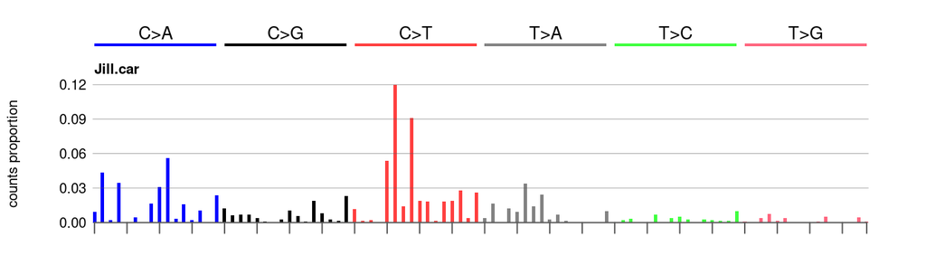

```r
pcat(Jill.car.sep$inferred.target.sig.as.catalog)
```

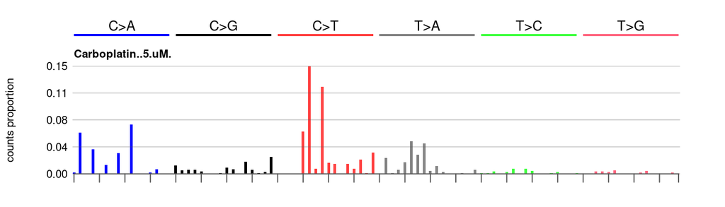

```r
# Signature derived in Jill's paper
Jill.car <- sig.all[,"Carboplatin..5.uM.", drop = FALSE]

pcat(as.catalog(Jill.car,catalog.type = "counts.signature", infer.rownames = TRUE))
```

```r
philentropy::cosine_dist(Jill.car.sep$inferred.target.sig.as.catalog,
                         as.matrix(sig.all[,"Carboplatin..5.uM.", drop = FALSE]), testNA = FALSE)
```

```
## [1] 0.959928
```

Overall pairwise cosine sim

```r
colnames <- c()
pw.sim = matrix(data=NA, nrow=1, ncol=0)
x=1
for (i in 1:(ncol(ts.car)-1)){
  for (j in (i+1):ncol(ts.car)){
    tmp.sim <- philentropy::cosine_dist(ts.car[,i,drop=FALSE],ts.car[,j,drop=FALSE], testNA=TRUE)
    colnames <- c(colnames, paste(colnames(ts.car)[i],
                                  colnames(ts.car)[j],
                                  sep="-"))
    pw.sim <- cbind(pw.sim, tmp.sim)
  }
}
colnames(pw.sim) <- colnames
rownames(pw.sim) <- names(tmp.sim)

pw.sim
```

```
##      carboplatin_s1-carboplatin_s2 carboplatin_s1-carboplatin_s3
## [1,]                     0.5933007                      0.749221
##      carboplatin_s2-carboplatin_s3
## [1,]                     0.6095529
```

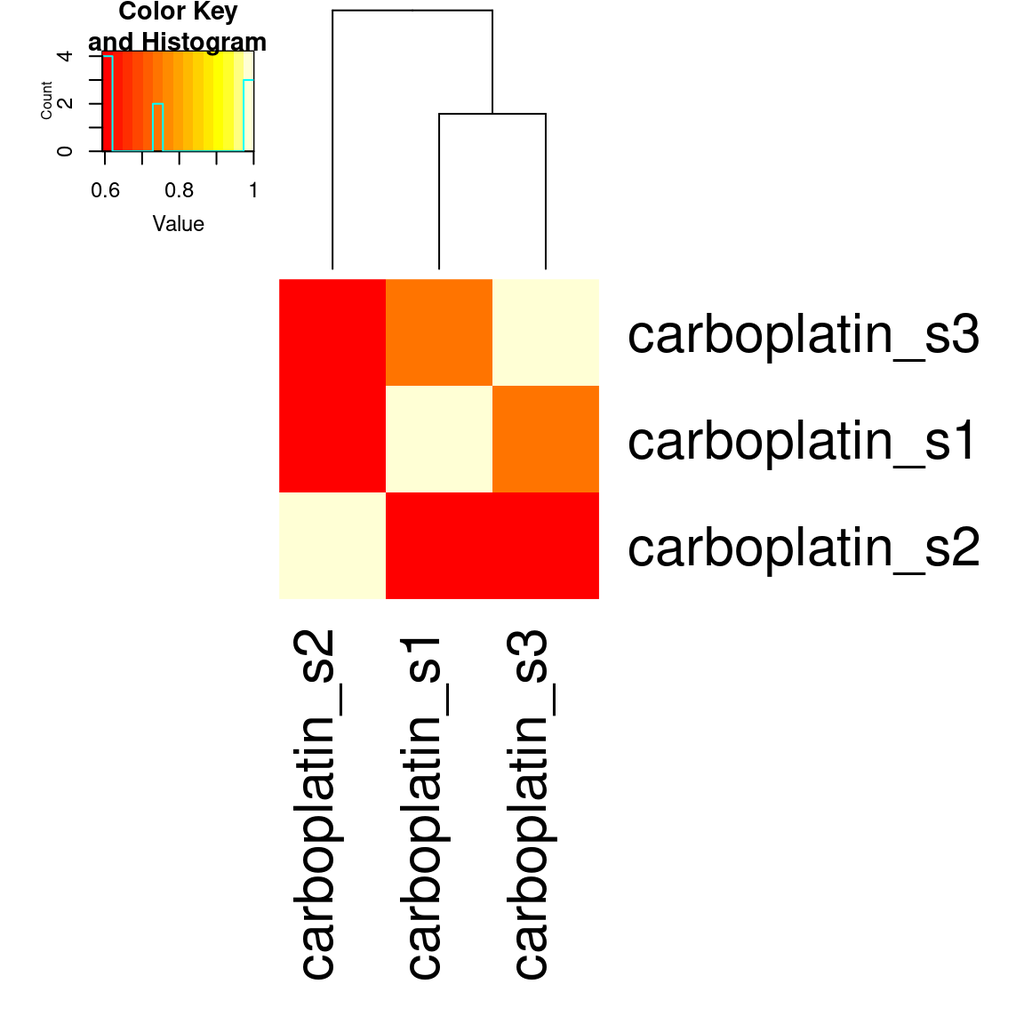

```r
cosine.sim <- suppressMessages(
  philentropy::distance(t(ts.car), method = "cosine"))

colnames(cosine.sim) <- colnames(ts.car)
rownames(cosine.sim) <- colnames(ts.car)
gplots::heatmap.2(x = cosine.sim,
                  dendrogram = "column",
                  margins = c(15, 15),
                  cex.axis = 0.5,
                  symm = TRUE,
                  trace = "none")
```

Weighted cosine sim

```r
colnames <- c()
pw.subsim <- c()
x=1
for (i in 1:(ncol(ts.car)-1)){
  for (j in (i+1):ncol(ts.car)){
    tmp.subsim <- subcolor_sim(ts.car[,i,drop=FALSE],ts.car[,j,drop=FALSE])[["weighted.avg"]]
    colnames <- c(colnames, paste(colnames(ts.car)[i],
                                  colnames(ts.car)[j],
                                  sep="-"))
    pw.subsim <- c(pw.subsim, tmp.subsim)
  }
}
names(pw.subsim) <- colnames
pw.subsim
```

```
## carboplatin_s1-carboplatin_s2 carboplatin_s1-carboplatin_s3
##                     0.5567880                     0.7279357
## carboplatin_s2-carboplatin_s3
##                     0.6166885
```

Cosine sim by color

```r
colnames <- c()
pw.subsim = matrix(data=NA, nrow=6, ncol=0)
x=1
for (i in 1:(ncol(ts.car)-1)){
  for (j in (i+1):ncol(ts.car)){
    tmp.subsim <- subcolor_sim(ts.car[,i,drop=FALSE],ts.car[,j,drop=FALSE])[["by.color"]]
    colnames <- c(colnames, paste(colnames(ts.car)[i],
                                  colnames(ts.car)[j],
                                  sep="-"))
    pw.subsim <- cbind(pw.subsim, tmp.subsim)
  }
}
colnames(pw.subsim) <- colnames
rownames(pw.subsim) <- names(tmp.subsim)

pw.subsim
```

```
##     carboplatin_s1-carboplatin_s2 carboplatin_s1-carboplatin_s3
## C>A                    0.02517465                     0.6504301
## C>G                    0.57313531                     0.4490632
## C>T                    0.86827221                     0.8769808
## T>A                    0.63968503                     0.8111703
## T>C                    0.13311645                    -0.4605491
## T>G                    0.26783502                     0.4023059
##     carboplatin_s2-carboplatin_s3
## C>A                    0.11405710
## C>G                    0.66514365
## C>T                    0.82787334
## T>A                    0.50864226
## T>C                   -0.28085187
## T>G                    0.02772775
```

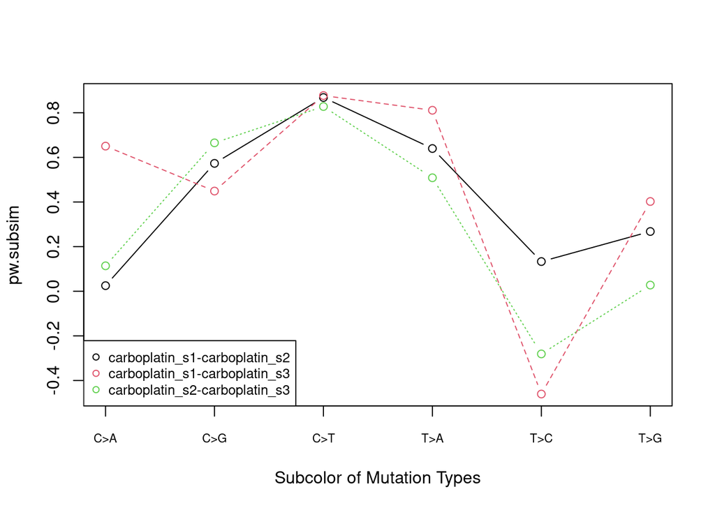

```r
matplot(pw.subsim, type = "b",pch=1, col = 1:21, xaxt = "n", xlab = "Subcolor of Mutation Types")
axis(1, at = 1:6, labels = rownames(pw.subsim), cex.axis = 0.7)
legend("bottomleft", legend = colnames(pw.subsim), col=1:21, pch=1, cex = 0.8)
```